## Infraestructura eléctrica por cuadrante

La capa `fallas_eventos` contiene un inventario georreferenciado de elementos de infraestructura eléctrica asociados a cada cuadrante. Pese a su nombre, esta capa **no registra eventos temporales de falla**: a partir de las columnas `TIPO`, `Name` y `CUADRANTE` se identifica que corresponde a un inventario físico de activos de red. Esta distinción se deja explícita aquí porque es relevante para la interpretación metodológica del panel.

Se identifican cinco tipos de elementos:

- Aisladero
- Cuchilla
- Interruptor
- Reconectador
- Transformador

La información se agrega a nivel de **cuadrante** para construir variables estructurales que posteriormente se incorporarán al panel utilizado para el pronóstico de SAIDI y SAIFI. Estas variables representan características estructurales de la red (exposición, complejidad, capacidad de protección/aislamiento) y no deben interpretarse como conteos de fallas.

### Paquetes

```r
library(sf)
library(dplyr)
library(tidyr)
library(knitr)
# Misma logica que Scripts/Edwin/analisis_correlacion.Rmd.
# Este Rmd vive en Scripts/Cindy/v4/ → el .env de la raiz esta 3 niveles arriba.
env_path <- file.path("..", "..", "..", ".env")
if (file.exists(".env")) {
  readRenviron(".env")
} else if (file.exists(env_path)) {
  readRenviron(env_path)
}

UBICACION_DATA <- Sys.getenv("UBICACION_DATA")
if (UBICACION_DATA == "") {
  stop("UBICACION_DATA no esta definida. Verifica el archivo .env.")
}

cat(sprintf("UBICACION_DATA: %s\n", UBICACION_DATA))
```

```
## UBICACION_DATA: D:/OneDrive - PUJ Cali/Projecto_Grado_Javeriana/Data_Project/
```

```r
DIR_IMAGENES <- file.path(
  UBICACION_DATA, "imagenes", "infraestructura_electrica_por_cuadrante"
)
dir.create(DIR_IMAGENES, recursive = TRUE, showWarnings = FALSE)
knitr::opts_chunk$set(
  fig.path = paste0(DIR_IMAGENES, "/"),
  dev = "png"
)
```

### Distribución de los elementos de infraestructura

```r
library(sf)

st_layers(file.path(UBICACION_DATA, "fallas_eventos.gpkg"))   # ver qué capas tiene
```

```
## Driver: GPKG
## Available layers:
##             layer_name geometry_type features fields crs_name
## 1       fallas_eventos         Point    47652      7   WGS 84
## 2 cuadrantes_poligonos Multi Polygon      344      4   WGS 84
```

```r
fallas_eventos<- st_read(file.path(UBICACION_DATA, "fallas_eventos.gpkg"), layer = "fallas_eventos")
cuadrantes_poligonos<-st_read(file.path(UBICACION_DATA, "fallas_eventos.gpkg"), layer = "cuadrantes_poligonos")
#st_crs(fallas_eventos)   # revisa el sistema de coordenadas
nrow(fallas_eventos)     # debería ser 47,652
```

```
## [1] 47652
```

```r
#head(fallas_eventos)
```

Antes de construir las variables se revisa la composición del inventario, para saber qué tipos de activos están disponibles y evaluar más adelante cuáles aportan mayor relevancia explicativa para SAIDI y SAIFI.

```r
tipos_infra <- fallas_eventos %>%
  st_drop_geometry() %>%
  count(TIPO, sort = TRUE)

kable(
  tipos_infra,
  caption = "Distribución de los elementos de infraestructura eléctrica"
)
```

Distribución de los elementos de infraestructura eléctrica

| TIPO | n |
| --- | --- |
| Transformador | 25405 |
| Aisladero | 19080 |
| Cuchilla | 2527 |
| Reconectador | 367 |
| Interruptor | 273 |

### Número de elementos de cada tipo por cuadrante

Se cuenta el número de elementos de cada tipo presente en cada cuadrante. Estas variables caracterizan la composición física de la red de distribución: un mayor número de elementos puede representar mayor extensión o complejidad de infraestructura expuesta a posibles interrupciones.

```r
infra_tipo <- fallas_eventos %>%
  st_drop_geometry() %>%
  count(CUADRANTE, TIPO, name = "n") %>%
  pivot_wider(
    names_from  = TIPO,
    values_from = n,
    values_fill = 0
  )
```

### Estandarización de nombres

Se utilizan nombres explícitos para facilitar la interpretación de las variables en los modelos posteriores.

**Corrección:** el `rename()` original asume que las cinco columnas (`Aisladero`, `Cuchilla`, `Interruptor`, `Reconectador`, `Transformador`) siempre existen tras el `pivot_wider()`. Si algún cuadrante o la muestra completa no contiene alguno de los cinco tipos, esa columna no se crea y el `rename()` fallará. Se agrega una verificación previa que crea en cero cualquier columna faltante, para que el pipeline no se rompa silenciosamente ni truene con un error críptico.

```r
tipos_esperados <- c(
  "Aisladero", "Cuchilla", "Interruptor", "Reconectador", "Transformador"
)

faltantes <- setdiff(tipos_esperados, names(infra_tipo))

if (length(faltantes) > 0) {
  infra_tipo[faltantes] <- 0
}

infra_cuadrante <- infra_tipo %>%
  rename(
    n_aisladeros      = Aisladero,
    n_cuchillas       = Cuchilla,
    n_interruptores   = Interruptor,
    n_reconectadores  = Reconectador,
    n_transformadores = Transformador
  )
```

### Número total de elementos de infraestructura

`n_elementos` representa el tamaño absoluto del inventario de infraestructura eléctrica localizado en cada cuadrante:

$$n\_elementos = aisladeros + cuchillas + interruptores + reconectadores +
transformadores$$

Un cuadrante con más elementos posee una mayor cantidad de activos potencialmente expuestos a fallas. **Importante:** esta variable representa exposición estructural y no debe interpretarse como número de fallas.

```r
infra_cuadrante <- infra_cuadrante %>%
  mutate(
    n_elementos =
      n_aisladeros +
      n_cuchillas +
      n_interruptores +
      n_reconectadores +
      n_transformadores
  )
```

### Número de tipos de infraestructura presentes

`n_tipos_infraestructura` mide la diversidad de tipos de activos presentes en cada cuadrante (rango 1 a 5) y busca aproximar la heterogeneidad de la red: un cuadrante con distintos tipos de activos puede tener una estructura más compleja que uno dominado por un solo tipo de elemento.

Dado que solo toma cinco valores posibles, **no se recomienda usarla como variable principal** del modelo de SAIDI/SAIFI; se conserva como indicador exploratorio de heterogeneidad, útil por ejemplo para estratificar cuadrantes o como control adicional.

```r
infra_cuadrante <- infra_cuadrante %>%
  mutate(
    n_tipos_infraestructura =
      rowSums(
        across(
          c(
            n_aisladeros,
            n_cuchillas,
            n_interruptores,
            n_reconectadores,
            n_transformadores
          )
        ) > 0
      )
  )
```

### Participación de cada tipo de infraestructura

Además del número absoluto de activos, se calcula la composición porcentual de la infraestructura, lo que permite diferenciar entre:

1. cuadrantes grandes, que simplemente tienen más activos, y
2. cuadrantes cuya red tiene una composición distinta (p. ej. mayor proporción de transformadores frente a elementos de protección).

**Corrección:** el cálculo original (`n_tipo / n_elementos`) genera `NaN` en cualquier cuadrante con `n_elementos == 0` (cero elementos de infraestructura registrados), porque divide entre cero. Ese `NaN` se propagaría a la verificación de proporciones y a cualquier modelo que use estas columnas. Se corrige forzando la proporción a `0` cuando no hay elementos, ya que conceptualmente un cuadrante sin infraestructura no tiene una composición definida, pero para efectos del panel es más seguro codificarlo como cero y no como valor faltante.

```r
infra_cuadrante <- infra_cuadrante %>%
  mutate(
    prop_aisladeros      = if_else(n_elementos == 0, 0, n_aisladeros      / n_elementos),
    prop_cuchillas       = if_else(n_elementos == 0, 0, n_cuchillas       / n_elementos),
    prop_interruptores   = if_else(n_elementos == 0, 0, n_interruptores   / n_elementos),
    prop_reconectadores  = if_else(n_elementos == 0, 0, n_reconectadores  / n_elementos),
    prop_transformadores = if_else(n_elementos == 0, 0, n_transformadores / n_elementos)
  )
```

### Organización de la tabla final

La tabla conserva el identificador espacial, las variables de escala, las cantidades por tipo de activo y las variables de composición. `CUADRANTE` se mantiene como identificador y no como variable numérica explicativa, dado que el número asignado al cuadrante no tiene significado cardinal.

```r
infra_cuadrante <- infra_cuadrante %>%
  select(
    CUADRANTE,

    # Variables de escala
    n_elementos,
    n_tipos_infraestructura,

    # Número de activos por tipo
    n_transformadores,
    n_aisladeros,
    n_cuchillas,
    n_interruptores,
    n_reconectadores,

    # Composición de la infraestructura
    prop_transformadores,
    prop_aisladeros,
    prop_cuchillas,
    prop_interruptores,
    prop_reconectadores
  )
```

### Revisión de la tabla

```r
str(infra_cuadrante)
```

```
## tibble [344 × 13] (S3: tbl_df/tbl/data.frame)
##  $ CUADRANTE              : num [1:344] 1 2 3 4 5 6 7 8 9 10 ...
##  $ n_elementos            : int [1:344] 1 20 15 26 1 2 77 47 7 84 ...
##  $ n_tipos_infraestructura: num [1:344] 1 2 3 2 1 1 4 3 2 2 ...
##  $ n_transformadores      : int [1:344] 1 12 4 18 1 2 36 25 5 43 ...
##  $ n_aisladeros           : int [1:344] 0 8 10 8 0 0 36 21 2 41 ...
##  $ n_cuchillas            : int [1:344] 0 0 1 0 0 0 4 1 0 0 ...
##  $ n_interruptores        : int [1:344] 0 0 0 0 0 0 0 0 0 0 ...
##  $ n_reconectadores       : int [1:344] 0 0 0 0 0 0 1 0 0 0 ...
##  $ prop_transformadores   : num [1:344] 1 0.6 0.267 0.692 1 ...
##  $ prop_aisladeros        : num [1:344] 0 0.4 0.667 0.308 0 ...
##  $ prop_cuchillas         : num [1:344] 0 0 0.0667 0 0 ...
##  $ prop_interruptores     : num [1:344] 0 0 0 0 0 0 0 0 0 0 ...
##  $ prop_reconectadores    : num [1:344] 0 0 0 0 0 ...
```

```r
head(infra_cuadrante)
```

```
## # A tibble: 6 × 13
##   CUADRANTE n_elementos n_tipos_infraestructura n_transformadores n_aisladeros
##       <dbl>       <int>                   <dbl>             <int>        <int>
## 1         1           1                       1                 1            0
## 2         2          20                       2                12            8
## 3         3          15                       3                 4           10
## 4         4          26                       2                18            8
## 5         5           1                       1                 1            0
## 6         6           2                       1                 2            0
## # ℹ 8 more variables: n_cuchillas <int>, n_interruptores <int>,
## #   n_reconectadores <int>, prop_transformadores <dbl>, prop_aisladeros <dbl>,
## #   prop_cuchillas <dbl>, prop_interruptores <dbl>, prop_reconectadores <dbl>
```

```r
summary(infra_cuadrante)
```

```
##    CUADRANTE       n_elementos      n_tipos_infraestructura n_transformadores
##  Min.   :  1.00   Min.   :   1.00   Min.   :1.000           Min.   :   0.00
##  1st Qu.: 86.75   1st Qu.:  40.75   1st Qu.:2.000           1st Qu.:  21.00
##  Median :172.50   Median :  94.00   Median :2.000           Median :  45.00
##  Mean   :172.50   Mean   : 138.52   Mean   :2.843           Mean   :  73.85
##  3rd Qu.:258.25   3rd Qu.: 151.00   3rd Qu.:4.000           3rd Qu.:  70.00
##  Max.   :344.00   Max.   :5276.00   Max.   :5.000           Max.   :3774.00
##   n_aisladeros     n_cuchillas      n_interruptores   n_reconectadores
##  Min.   :  0.00   Min.   :  0.000   Min.   : 0.0000   Min.   : 0.000
##  1st Qu.: 15.00   1st Qu.:  0.000   1st Qu.: 0.0000   1st Qu.: 0.000
##  Median : 44.00   Median :  0.000   Median : 0.0000   Median : 0.000
##  Mean   : 55.47   Mean   :  7.346   Mean   : 0.7936   Mean   : 1.067
##  3rd Qu.: 75.00   3rd Qu.:  5.000   3rd Qu.: 0.0000   3rd Qu.: 1.000
##  Max.   :684.00   Max.   :675.000   Max.   :58.0000   Max.   :85.000
##  prop_transformadores prop_aisladeros  prop_cuchillas    prop_interruptores
##  Min.   :0.0000       Min.   :0.0000   Min.   :0.00000   Min.   :0.000000
##  1st Qu.:0.4435       1st Qu.:0.3539   1st Qu.:0.00000   1st Qu.:0.000000
##  Median :0.5048       Median :0.4628   Median :0.00000   Median :0.000000
##  Mean   :0.5488       Mean   :0.4142   Mean   :0.02699   Mean   :0.006076
##  3rd Qu.:0.5964       3rd Qu.:0.5201   3rd Qu.:0.04145   3rd Qu.:0.000000
##  Max.   :1.0000       Max.   :0.6870   Max.   :0.25000   Max.   :1.000000
##  prop_reconectadores
##  Min.   :0.000000
##  1st Qu.:0.000000
##  Median :0.000000
##  Mean   :0.003963
##  3rd Qu.:0.006623
##  Max.   :0.055556
```

### Verificación de consistencia

Se verifica que la suma de los elementos clasificados por tipo coincida con el número total de elementos. La diferencia debe ser cero en todos los cuadrantes.

```r
infra_cuadrante <- infra_cuadrante %>%
  mutate(
    verificacion_total =
      n_elementos -
      (
        n_aisladeros +
        n_cuchillas +
        n_interruptores +
        n_reconectadores +
        n_transformadores
      )
  )

table(infra_cuadrante$verificacion_total)
```

```
##
##   0
## 344
```

### Verificación de las participaciones

Las participaciones de los cinco tipos deben sumar 1 en cada cuadrante con `n_elementos > 0`. Con la corrección del paso anterior, los cuadrantes sin elementos suman 0 (no 1), así que la verificación se hace por separado para cada caso y así evita interpretar un 0 legítimo como un error de cálculo.

```r
infra_cuadrante <- infra_cuadrante %>%
  mutate(
    verificacion_proporciones =
      prop_aisladeros +
      prop_cuchillas +
      prop_interruptores +
      prop_reconectadores +
      prop_transformadores
  )

# Cuadrantes con elementos: la suma debe ser 1 (o 0 si no aplica)
summary(
  infra_cuadrante$verificacion_proporciones[infra_cuadrante$n_elementos > 0]
)
```

```
##    Min. 1st Qu.  Median    Mean 3rd Qu.    Max.
##       1       1       1       1       1       1
```

```r
# Cuadrantes sin elementos: la suma debe ser exactamente 0
table(
  infra_cuadrante$verificacion_proporciones[infra_cuadrante$n_elementos == 0]
)
```

```
## < table of extent 0 >
```

### Exportar tabla de infraestructura

La tabla se guarda como CSV para facilitar su integración posterior con el panel de SAIDI y SAIFI.

```r
write.csv(
  infra_cuadrante,
  file.path(UBICACION_DATA, "infraestructura_por_cuadrante.csv"),
  row.names   = FALSE,
  fileEncoding = "UTF-8"
)
```

### Qué se construyó conceptualmente

| Variable | Qué mide | Relevancia potencial |
| --- | --- | --- |
| `n_elementos` | Tamaño total de la infraestructura | Exposición/escala de la red |
| `n_transformadores` | Cantidad de transformadores | Escala y estructura de la red |
| `n_aisladeros` | Cantidad de aisladeros | Composición y extensión de la red |
| `n_cuchillas` | Cantidad de cuchillas | Seccionamiento de la red |
| `n_interruptores` | Cantidad de interruptores | Protección y operación |
| `n_reconectadores` | Cantidad de reconectadores | Protección, aislamiento y operación |
| `n_tipos_infraestructura` | Diversidad de activos | Heterogeneidad estructural (exploratoria) |
| `prop_*` | Composición relativa | Estructura de la red, independiente de su tamaño |

**Advertencia para la especificación del modelo:** no se deben incluir todas estas variables simultáneamente, porque `n_elementos` es exactamente la suma de los cinco conteos por tipo, y las cinco `prop_*` suman exactamente 1 (colinealidad perfecta por construcción). Al especificar el modelo de SAIDI/SAIFI habrá que optar por **escala**, por **composición**, o por una combinación específicamente justificada (p. ej. `n_elementos` + cuatro de las cinco `prop_*`, dejando una como categoría base).

## Análisis gráfico de la infraestructura eléctrica por cuadrante

Esta sección complementa la construcción de `infra_cuadrante` con visualizaciones exploratorias, con el objetivo de entender cómo se distribuye la infraestructura entre cuadrantes antes de decidir qué variables entran al modelo de SAIDI/SAIFI.

```r
library(ggplot2)
library(dplyr)
library(tidyr)
library(scales)
```

### Distribución del tamaño de infraestructura

El histograma muestra si la mayoría de cuadrantes tiene pocos elementos y unos pocos concentran mucha infraestructura (cola larga), patrón común en redes de distribución.

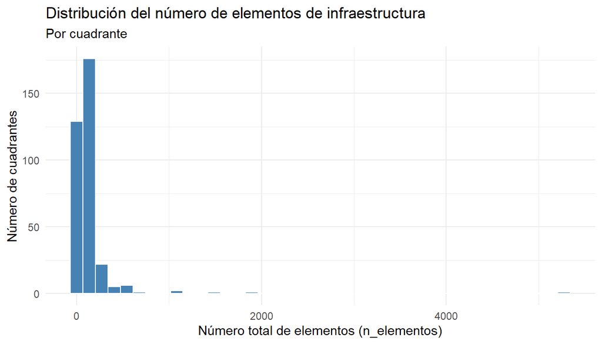

```r
ggplot(infra_cuadrante, aes(x = n_elementos)) +
  geom_histogram(bins = 40, fill = "steelblue", color = "white") +
  labs(
    title    = "Distribución del número de elementos de infraestructura",
    subtitle = "Por cuadrante",
    x        = "Número total de elementos (n_elementos)",
    y        = "Número de cuadrantes"
  ) +
  theme_minimal()
```

### Composición promedio de la infraestructura por tipo

Se calcula el promedio de cada `prop_*` a nivel general para ver qué tipo de elemento domina la red en términos relativos.

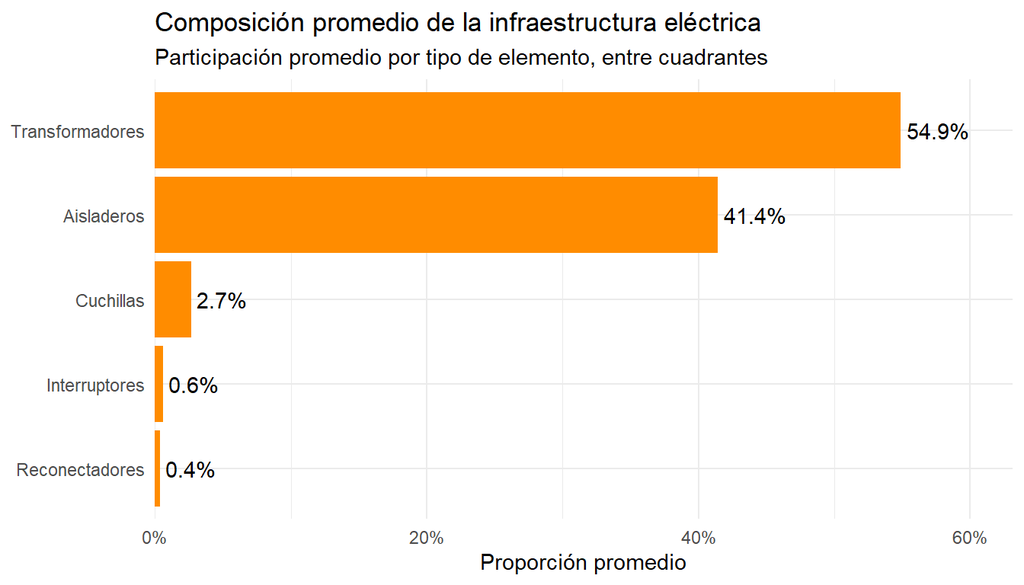

```r
composicion_promedio <- infra_cuadrante %>%
  summarise(
    Transformadores = mean(prop_transformadores),
    Aisladeros      = mean(prop_aisladeros),
    Cuchillas       = mean(prop_cuchillas),
    Interruptores   = mean(prop_interruptores),
    Reconectadores  = mean(prop_reconectadores)
  ) %>%
  pivot_longer(
    everything(),
    names_to  = "tipo",
    values_to = "proporcion_promedio"
  )

ggplot(composicion_promedio, aes(x = reorder(tipo, proporcion_promedio), y = proporcion_promedio)) +
  geom_col(fill = "darkorange") +
  geom_text(aes(label = percent(proporcion_promedio, accuracy = 0.1)), hjust = -0.1) +
  coord_flip() +
  scale_y_continuous(labels = percent, expand = expansion(mult = c(0, 0.15))) +
  labs(
    title    = "Composición promedio de la infraestructura eléctrica",
    subtitle = "Participación promedio por tipo de elemento, entre cuadrantes",
    x        = NULL,
    y        = "Proporción promedio"
  ) +
  theme_minimal()
```

### Composición por cuadrante (top 30 por tamaño)

Con 344 cuadrantes no es legible graficar todos en un solo eje. Se muestran los 30 cuadrantes con más infraestructura, para ver si la composición cambia con el tamaño de la red.

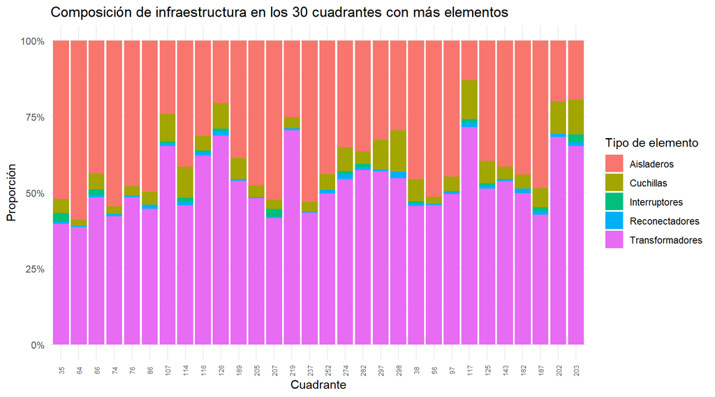

```r
top_cuadrantes <- infra_cuadrante %>%
  slice_max(n_elementos, n = 30) %>%
  select(CUADRANTE, starts_with("prop_")) %>%
  pivot_longer(
    starts_with("prop_"),
    names_to  = "tipo",
    values_to = "proporcion"
  ) %>%
  mutate(
    tipo = recode(
      tipo,
      prop_transformadores = "Transformadores",
      prop_aisladeros      = "Aisladeros",
      prop_cuchillas       = "Cuchillas",
      prop_interruptores   = "Interruptores",
      prop_reconectadores  = "Reconectadores"
    )
  )

ggplot(top_cuadrantes, aes(x = reorder(factor(CUADRANTE), -proporcion), y = proporcion, fill = tipo)) +
  geom_col() +
  scale_y_continuous(labels = percent) +
  labs(
    title = "Composición de infraestructura en los 30 cuadrantes con más elementos",
    x     = "Cuadrante",
    y     = "Proporción",
    fill  = "Tipo de elemento"
  ) +
  theme_minimal() +
  theme(axis.text.x = element_text(angle = 90, vjust = 0.5, size = 6))
```

### Diversidad de infraestructura

Distribución del número de cuadrantes según cuántos tipos distintos de elementos (1 a 5) contienen. Es la variable exploratoria de heterogeneidad documentada previamente en este `.Rmd`.

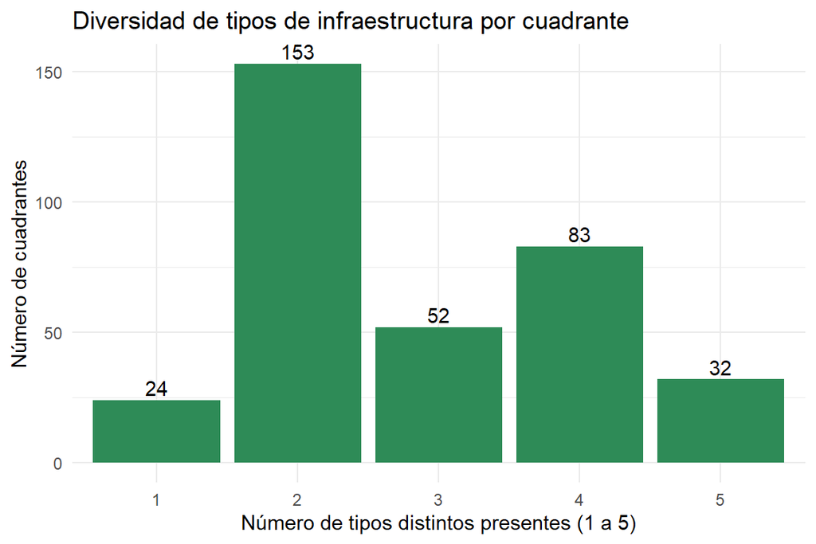

```r
ggplot(infra_cuadrante, aes(x = factor(n_tipos_infraestructura))) +
  geom_bar(fill = "seagreen") +
  geom_text(stat = "count", aes(label = after_stat(count)), vjust = -0.3) +
  labs(
    title = "Diversidad de tipos de infraestructura por cuadrante",
    x     = "Número de tipos distintos presentes (1 a 5)",
    y     = "Número de cuadrantes"
  ) +
  theme_minimal()
```

### Relación entre escala y diversidad

Boxplot de `n_elementos` según `n_tipos_infraestructura`, para verificar si cuadrantes con más tipos de activos también tienden a tener más elementos en total, o si ambas variables aportan información distinta al modelo.

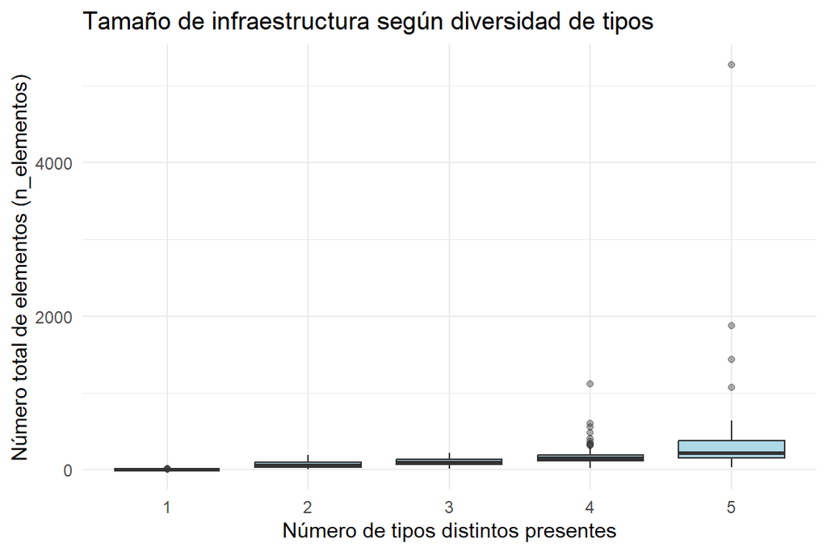

```r
ggplot(infra_cuadrante, aes(x = factor(n_tipos_infraestructura), y = n_elementos)) +
  geom_boxplot(fill = "lightblue", outlier.alpha = 0.4) +
  labs(
    title = "Tamaño de infraestructura según diversidad de tipos",
    x     = "Número de tipos distintos presentes",
    y     = "Número total de elementos (n_elementos)"
  ) +
  theme_minimal()
```

### Mapa interactivo: infraestructura eléctrica por cuadrante

```r
library(leaflet)
```

```r
library(sf)
library(dplyr)

# ----------------------------------------------------------------
# 1. Unir infra_cuadrante a la geometría real de los cuadrantes
# ----------------------------------------------------------------

cuadrantes_infra <- cuadrantes_poligonos %>%
  left_join(infra_cuadrante, by = "CUADRANTE") %>%
  st_transform(4326)

fallas_eventos <- st_transform(fallas_eventos, 4326)

# ----------------------------------------------------------------
# 2. Variables a mapear (todas las numéricas de interés)
# ----------------------------------------------------------------
#
# Se excluyen las columnas de verificación (no son variables de
# interpretación, solo controles de calidad).
# ----------------------------------------------------------------

variables_mapa <- c(
  n_elementos              = "N° total de elementos",
  n_tipos_infraestructura  = "N° de tipos de infraestructura",
  n_transformadores        = "N° de transformadores",
  n_aisladeros             = "N° de aisladeros",
  n_cuchillas              = "N° de cuchillas",
  n_interruptores          = "N° de interruptores",
  n_reconectadores         = "N° de reconectadores",
  prop_transformadores     = "Proporción de transformadores",
  prop_aisladeros          = "Proporción de aisladeros",
  prop_cuchillas           = "Proporción de cuchillas",
  prop_interruptores       = "Proporción de interruptores",
  prop_reconectadores      = "Proporción de reconectadores"
)

# ----------------------------------------------------------------
# 3. Paleta y etiqueta por variable
# ----------------------------------------------------------------
#
# Las proporciones (0-1) usan una paleta distinta de las variables
# de conteo, para que la escala de color sea interpretable en
# ambos casos.
# ----------------------------------------------------------------

crear_paleta <- function(var) {
  if (grepl("^prop_", var)) {
    colorNumeric("PuBuGn", domain = cuadrantes_infra[[var]])
  } else {
    colorNumeric("YlOrRd", domain = cuadrantes_infra[[var]])
  }
}

# ----------------------------------------------------------------
# 4. Mapa base
# ----------------------------------------------------------------

mapa_infra <- leaflet() %>%
  addProviderTiles(providers$CartoDB.Positron)

# ----------------------------------------------------------------
# 5. Una capa de polígonos (coropleta) por variable
# ----------------------------------------------------------------

for (var in names(variables_mapa)) {

  etiqueta <- variables_mapa[[var]]
  pal      <- crear_paleta(var)
  valores  <- cuadrantes_infra[[var]]

  mapa_infra <- mapa_infra %>%
    addPolygons(
      data = cuadrantes_infra,
      fillColor = pal(valores),
      fillOpacity = 0.65,
      color = "gray40",
      weight = 0.6,
      opacity = 0.8,
      label = paste0(
        "Cuadrante ", cuadrantes_infra$CUADRANTE,
        ": ", round(valores, 3), " (", etiqueta, ")"
      ),
      group = etiqueta
    )
}

# ----------------------------------------------------------------
# 6. Puntos individuales por tipo de elemento
# ----------------------------------------------------------------

tipos <- unique(fallas_eventos$TIPO)

pal_tipo <- colorFactor(
  palette = c(
    "Transformador" = "#1f78b4",
    "Aisladero"     = "#33a02c",
    "Cuchilla"      = "#ff7f00",
    "Reconectador"  = "#e31a1c",
    "Interruptor"   = "#6a3d9a"
  ),
  domain = tipos
)

for (t in tipos) {
  datos_tipo <- fallas_eventos %>% filter(TIPO == t)
  mapa_infra <- mapa_infra %>%
    addCircleMarkers(
      data = datos_tipo,
      radius = 3,
      color = ~pal_tipo(TIPO),
      stroke = FALSE,
      fillOpacity = 0.7,
      label = ~paste0(Name, " - ", TIPO, " (Cuadrante ", CUADRANTE, ")"),
      group = t
    )
}

# ----------------------------------------------------------------
# 7. Control de capas
# ----------------------------------------------------------------
#
# Todas las coropletas van en baseGroups: son mutuamente
# excluyentes, ver una desactiva las demás automáticamente. Los
# tipos de elemento son overlayGroups, combinables entre sí.
#
# NOTA: no se agrega addLegend() por cada variable, porque con 12
# variables saturaría el mapa con 12 leyendas simultáneas y no hay
# forma nativa en leaflet de mostrar solo la leyenda de la capa
# base activa. Se deja la etiqueta (label) de cada polígono como
# referencia al pasar el mouse.
# ----------------------------------------------------------------

mapa_infra <- mapa_infra %>%
  addLayersControl(
    baseGroups = unname(variables_mapa),
    overlayGroups = tipos,
    options = layersControlOptions(collapsed = FALSE)
  )

mapa_infra
```

[interactive chart not shown]

```r
library(htmlwidgets)

saveWidget(
  mapa_infra,
  file = file.path(UBICACION_DATA, "mapa_infraestructura_cuadrantes.html"),
  selfcontained = TRUE
)
library(sf)

ruta_gpkg <- file.path(UBICACION_DATA, "infraestructura_cuadrantes.gpkg")

# ----------------------------------------------------------------
# Capa 1: puntos individuales de infraestructura (47,652 elementos)
# ----------------------------------------------------------------
st_write(
  fallas_eventos,
  ruta_gpkg,
  layer = "fallas_eventos",
  delete_layer = TRUE
)
```

```
## Deleting layer `fallas_eventos' using driver `GPKG'
## Writing layer `fallas_eventos' to data source
##   `D:/OneDrive - PUJ Cali/Projecto_Grado_Javeriana/Data_Project//infraestructura_cuadrantes.gpkg' using driver `GPKG'
## Writing 47652 features with 7 fields and geometry type Point.
```

```r
# ----------------------------------------------------------------
# Capa 2: polígonos de cuadrantes CON todas las variables agregadas
# (n_elementos, n_tipos_infraestructura, conteos y proporciones)
# ----------------------------------------------------------------
st_write(
  cuadrantes_infra,
  ruta_gpkg,
  layer = "cuadrantes_infra",
  delete_layer = TRUE
)
```

```
## Deleting layer `cuadrantes_infra' using driver `GPKG'
## Writing layer `cuadrantes_infra' to data source
##   `D:/OneDrive - PUJ Cali/Projecto_Grado_Javeriana/Data_Project//infraestructura_cuadrantes.gpkg' using driver `GPKG'
## Writing 344 features with 18 fields and geometry type Multi Polygon.
```

```r
# ----------------------------------------------------------------
# Verificación: confirmar que ambas capas quedaron guardadas
# ----------------------------------------------------------------
st_layers(ruta_gpkg)
```

```
## Driver: GPKG
## Available layers:
##         layer_name geometry_type features fields crs_name
## 1   fallas_eventos         Point    47652      7   WGS 84
## 2 cuadrantes_infra Multi Polygon      344     18   WGS 84
```

# así se cargaría la capa

```r
#
# ruta_gpkg <- file.path(UBICACION_DATA, "infraestructura_cuadrantes.gpkg")
# fallas_eventos    <- st_read(ruta_gpkg, layer = "fallas_eventos")
# cuadrantes_infra  <- st_read(ruta_gpkg, layer = "cuadrantes_infra")
```